# 数据集异常值处理

在开始学习前，需要首先对训练数据集中的异常值进行处理。可能遇到的异常值可能有以下几类：

1. 错误数据，例如不是猫也不是狗的照片
2. 无效数据，例如虽然可能是猫或狗的照片，但几乎无法分辨
3. 质量较差的数据，例如照片分辨率很低，或者模糊等

对这几种情况，会采取不同的处理方式：对错误数据和无效数据应予以删除；而对质量较差的数据，还属于有效数据，应该保留。

## 检测异常值

检测方法是，先使用经过 ImageNet 数据集训练的现成模型对所有训练数据进行一次预测。该模型会输出对图片进行 1000 种分类的预测结果，将其中预测为猫和狗的照片视为有效数据，对剩下的数据进行人工观测及处理。

## 准备工作

```python
import numpy as np

import re
import os
import h5py
import shutil

from keras.models import Model
from keras.layers import Flatten, Dropout, Dense
from keras.preprocessing.image import load_img
from keras.applications import vgg16

from math import ceil
from image import MyImageDataGenerator

import keras.backend as K
K.set_image_data_format('channels_last')

import matplotlib.pyplot as plt
%matplotlib inline

CWD = os.getcwd()
ORIG_TRAIN_IMAGES_DIR = CWD + '/train/'
ABNORMAL_DIR = CWD + '/images/abnormal/'
```

```python
def link_files(src, dest, fnames):
    if os.path.exists(dest):
        shutil.rmtree(dest)

    os.makedirs(dest)

    for fname in fnames:
        os.symlink(src + fname, dest + fname)
```

```python
dest = ABNORMAL_DIR + 'abnormal/'
src = ORIG_TRAIN_IMAGES_DIR
train_fnames = os.listdir(ORIG_TRAIN_IMAGES_DIR)

link_files(src, dest, train_fnames)
```

## 对训练数据集进行预测

这里选择 VGG16 模型进行预测，并将预测结果保存在 H5 文件中，便于在本地电脑对图片进行人工处理。

```python
IDG = MyImageDataGenerator(preprocessing_function=vgg16.preprocess_input)
train_generator = IDG.flow_from_directory(ABNORMAL_DIR, (224, 224), shuffle=False, batch_size=16)

model = vgg16.VGG16(include_top=True, weights='imagenet', pooling='avg')
predict = model.predict_generator(train_generator, ceil(train_generator.samples / 16), verbose=1)
```

```
Found 25000 images belonging to 1 classes.
```

完成预测后，按照分类可能性最大的原则提取分类结果。然后对所有分类名称进行观察，首先提取其中猫和狗的分类。其次，考虑到这是一个比较原始的模型，一些接近猫狗的分类，也视为有效数据。例如，分类为狮子或狼的照片，有很大可能性是对猫和狗误判。

排除有效数据后，将剩余照片导入单独的文件夹，并进行人工观察。

```python
predict_types = vgg16.decode_predictions(predict, top=1)

type_sets = set()
saved_fnames = []
saved_types = []

for i, x in enumerate(predict_types):
    saved_fnames.append(np.string_(train_fnames[i]))
    saved_types.append(np.string_(x[0][1]))
    type_sets.add(x[0][1])

print(len(type_sets))
print()
print(type_sets)

# 将预测保存在文件中，以便 AWS 用户在本地观察和处理图片
saved_fnames = np.array(saved_fnames)
saved_fnames = np.expand_dims(saved_fnames, axis=1)
saved_types = np.array(saved_types)
saved_types = np.expand_dims(saved_types, axis=1)

h5fname = 'vgg16.h5'

if os.path.exists(h5fname):
    os.remove(h5fname)

with h5py.File(h5fname, 'w') as f:
    f.create_dataset('predicts', data=saved_types)
    f.create_dataset('fnames', data=saved_fnames)
```

[output not shown]

```python
cat_names = ['cat', 'egyptian', 'persian', 'kitty', 'puss', 'tiger', 'angora', 'tom', 'siamese', 'manx', 'maltese', 'tabby', 'burmese', 'alley', 'abyssinian', 'queen', 'tortoiseshell', 'mouser']
dog_names = ['dog', 'Saluki', 'Cardigan', 'Pembroke', 'Appenzeller', 'Samoyed', 'pinscher', 'malamute', 'malinois', 'Shih-Tzu', 'kelpie', 'short-haired_pointer', 'boxer', 'springer', 'Mexican_hairless', 'hyena', 'Rottweiler', 'collie', 'setter', 'teddy', 'kuvasz', 'redbone', 'Weimaraner', 'bluetick', 'Great_Dane', 'Pekinese', 'briard', 'papillon', 'shepherd', 'ridgeback', 'groenendael', 'Dandie_Dinmont', 'beagle', 'EntleBucher', 'elkhound', 'spaniel', 'dalmatian', 'mastiff', 'doberman', 'pooch', 'doddie', 'doggy', 'barker', 'bow-wow', 'dalmatian', 'cur', 'mongrel', 'mutt', 'corgi', 'mexican hairless', 'newfoundland', 'poodle', 'basenji', 'leonberg', 'griffon', 'pug', 'spitz', 'pyrenees', 'toy', 'puppy', 'schipperke', 'bouvier_des_flandres', 'boston_bull', 'japanese_spaniel', 'airedale', 'husky', 'whippet', 'border_collie', 'chihuahua', 'schnauzer', 'pomeranian', 'terrier', 'saint_bernard', 'retriever', 'vizsla', 'komondor', 'cocker_spaniel', 'dingo', 'hound', 'chow', 'borzoi', 'affenpinscher', 'Pomeranian', 'keeshond', 'basset', 'dhole']
animal_names = ['lion', 'wild_boar', 'mink', 'hare', 'marmoset', 'weasel', 'wombat', 'cougar', 'skunk', 'cheetah', 'mongoose', 'fox', 'lynx', 'meerkat', 'lesser_panda', 'coyote', 'ferret', 'wolf', 'patas', 'otter', 'badger', 'beaver', 'snow_leopard']

names = cat_names + dog_names + animal_names
pattern = re.compile('|'.join(names), re.I)

abnormals = [(i, x[0][1]) for i, x in enumerate(predict_types) if not pattern.search(x[0][1])]

print('found: ', len(abnormals))
```

```
found:  1780
```

```python
abnormal_fnames = []

for item in abnormals:
    abnormal_fnames.append(train_fnames[item[0]])

link_files(src, dest, abnormal_fnames)
```

```
fname:  cat.1069.jpg
predict:  quilt
```

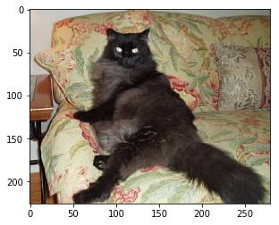

```
fname:  dog.173.jpg
predict:  shopping_cart
```

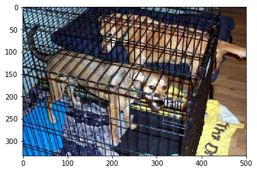

```
fname:  cat.8676.jpg
predict:  tub
```

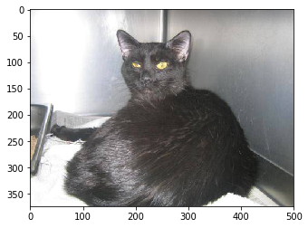

```
fname:  cat.7558.jpg
predict:  mousetrap
```

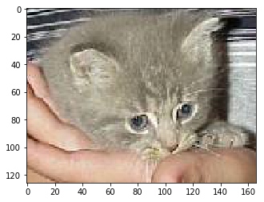

```
fname:  cat.10930.jpg
predict:  television
```

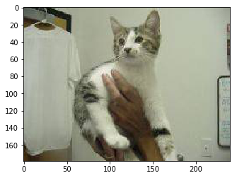

```python
group = 0
batch = 5

for i in range(group * batch, (group + 1) * batch):
    sm = abnormals[i]
    print('fname: ', train_fnames[sm[0]])
    print('predict: ', sm[1])

    img = load_img(ORIG_TRAIN_IMAGES_DIR + train_fnames[sm[0]])
    plt.imshow(img)
    plt.show()
```